# Federal Anchor Transmission: A Proposal for Interregional Buildout Through Federally-Built Clean Firm Generation

# Federal Anchor Transmission: A Proposal for Interregional Buildout Through Federally-Built Clean Firm Generation

*Fred Stafford · fred@publicpowerreview.org* *Version 2.0 · May 20, 2026*

## Executive Summary

The United States built its great mid-century interregional transmission corridors — the Pacific Northwest–Southwest Intertie most prominently — by combining two federal innovations of the New Deal era. Generation was built and owned by the federal government on its balance sheet, principally through the Bureau of Reclamation and the U.S. Army Corps of Engineers, with construction risk borne federally. Marketing was handled by Power Marketing Administrations and by public utilities like the Tennessee Valley Authority under a statutory **preference principle**: public power entities got first call on federal generation output at cost-of-service rates, with investor-owned utilities receiving secondary access to surplus.

This proposal generalizes that New Deal model to the 21st-century clean firm generation challenge. The Federal Anchor Transmission Program calls for a portfolio of new federally-built nuclear plants (initially Westinghouse AP1000s, extensible to SMRs and other federally-supported clean firm generation) deployed on pre-assessed publicly-owned sites, transferred at commercial operation to qualifying publicly-owned utilities at defined acquisition prices, with construction-cost overruns above acquisition prices absorbed on the federal balance sheet, and with associated interregional transmission built as jointly-owned segmented projects on the Pacific Intertie model.

**The proposal’s defining innovation is a modernized public-preference principle.** Where the New Deal version offered public power entities preference in wholesale electricity pricing, this proposal offers public power entities preference in two federal supports: federal cost-overrun insurance for new clean firm plants they acquire, and federal financing and siting authority for interregional transmission anchored to those plants. Only publicly-owned utilities can be acquiring entities for federally-built plants; investor-owned utilities can be transmission partners, wholesale buyers, and retail offtake intermediaries for hyperscaler customers, but cannot be acquirers and cannot directly receive federal construction-risk absorption. This preserves the New Deal’s structural separation between public and private utilities while updating the substance of what the preference confers — from price subsidy to risk subsidy.

**Version 2.0 introduces three substantial extensions beyond Version 1.0.** First, the anchor lines are explicitly sized with a defined reliability vintage on top of the contracted vintage — 300-500 MW per line of bidirectional emergency exchange capability that addresses the resource adequacy use case (Winter Storm Elliott-type events) that the contracted-vintage-only sizing didn’t fully realize. Second, both nuclear construction cost overruns and reliability vintage carrying cost are recovered through a generalized layered cost recovery architecture in which every constituency with structural interest pays a defined share calibrated to its benefit incidence — POUs, destination IOUs, hyperscalers, and the federal government each absorbing bounded layers of both stacks. Third, the original Nuclear Construction Reserve Fund expands to a Federal Anchor Program Reserve Fund administering both layers under unified administration, with hyperscaler contributions in the $18-27/MWh range covering the largest share of both stacks and construction-period advance contributions (CWIP-style) providing bootstrap reserves.

The principal initial pilot is the Tennessee Valley Authority, which brings an operating nuclear workforce, pre-assessed never-completed large nuclear sites (Bellefonte in Alabama, Hartsville in Tennessee, Yellow Creek in Mississippi, plus Clinch River for SMR development), and direct geographic adjacency to four of the highest-growth IOU data center markets (Southern Company in Georgia, Duke in the Carolinas, Dominion in Virginia, Entergy Mississippi in Central MS). The framework extends to other qualifying publicly-owned utilities (NYPA, NPPD, LADWP, and others) in Phase 2.

The proposal lives in tension with the interregional transmission advocate community (Grid Strategies, ACEG, Brattle, ESIG, Niskanen, RMI) whose consensus position is that any uncommitted interregional capacity should be compensated through ELCC accreditation and market-eligible dispatch rather than walled off as appropriations-funded reserve. The proposal’s design choice — to reserve the reliability vintage for emergency exchange use with explicit statutory protections against commercial dispatch market participation — is structurally defensible but politically demanding, requiring sustained advocacy that frames the reliability vintage as reserved infrastructure paid for under a defined cost recovery architecture rather than as wasted capacity awaiting commercialization.

## The Problem

After two decades of essentially flat electricity demand, U.S. load is growing again — driven primarily by data centers and AI infrastructure, but also by electrification, manufacturing reshoring, and dispatchable thermal retirements. TVA reports data center load reached 18% of its industrial demand in 2025 and is projected to double by 2030; similar trajectories are reported by Dominion, Duke, Southern Company, and Entergy Mississippi. Most utilities cannot independently build enough generation to meet projected load growth on the timeline required.

The obvious solution is interregional transmission. Multiple studies — DOE’s National Transmission Needs Study, MIT’s *The Future of the Electric Grid*, NREL’s interconnection studies — converge on the conclusion that the U.S. needs roughly double its current interregional transfer capacity to meet 2040 demand reliably. Beyond economic dispatch, interregional transmission delivers substantial resource adequacy benefits through geographic diversity: load peaks, weather stress, and generation forced outages don’t coincide across regions, so utilities connected by adequate interregional capacity need less redundant in-region capacity to meet reliability targets.

Winter Storm Elliott in December 2022 demonstrated this concretely and painfully for the exact region this proposal targets. Extreme cold across the Southeast caused widespread natural gas plant forced outages, and both TVA and Duke Energy Carolinas were forced to implement rolling blackouts on December 23–24, 2022 — the first such events in either utility’s history. Limited interregional transfer capacity meant the Southeast could not adequately draw on power from regions experiencing different conditions. The episode made the resource adequacy case for interregional transmission in the TVA and neighboring IOU footprint not theoretical but operationally urgent.

The problem is that modern interregional transmission projects die at the cost-allocation stage. The Grain Belt Express, MISO MVP, and similar projects spent decades in regulatory and political conflict over which utilities and which ratepayers should bear which share of capital costs. The federal toolkit has expanded substantially (FERC Order 2222, FERC Order 1000, DOE Transmission Facilitation Program, Inflation Reduction Act tax credits, the Department of Commerce’s October 2025 $80 billion AP1000 partnership, the Office of Energy Dominance Financing) but the cost-allocation barrier remains stubborn. The federal anchor program resolves the barrier through anchor framing and segmented ownership — federal generation gives the line a specific resource-to-load story; segmented ownership settles cost allocation through who owns what.

## Two Federal Precedents

The proposal draws on two distinct New Deal-era federal infrastructure templates whose combination has not been previously theorized but whose individual components are well-established.

**The Bureau of Reclamation / BPA Model.** Columbia River federal hydropower was built and owned by federal agencies (Bureau of Reclamation, Army Corps of Engineers) on the federal balance sheet, with construction risk borne federally. The Bonneville Power Administration was created as a Power Marketing Administration to market the output under statutory preference for public power and cooperatives. The model demonstrates that federal construction with public-utility operation works at scale: BPA has operated reliably for nearly 90 years, Columbia River federal hydropower has been the foundation of Pacific Northwest electricity supply, and the underlying construction-risk architecture (federal balance sheet absorption with public-utility operational stewardship) has proven durable across multiple political eras.

**The Pacific Intertie.** The 1964 Pacific Northwest–Southwest Intertie connected federal hydropower in the Pacific Northwest to load centers in California through a joint segmented transmission architecture: BPA owned the northern segments, LADWP owned the southern segments, and California IOUs (Pacific Gas & Electric, Southern California Edison, San Diego Gas & Electric) owned segments and converter stations in their territories. Each utility recovered its segment’s capital from its own customers; cost allocation was settled through ownership rather than through contested allocation methodology. The Intertie has operated reliably for sixty years, moves roughly 8,000 MW between regions, and has paid for itself many times over in delivered economic and reliability value.

Together, the BoR/BPA construction model and the Pacific Intertie’s segmented-ownership transmission model provide a coherent template for federally-anchored interregional buildout. The first solves construction-risk absorption and capital formation; the second solves cost-allocation and IOU alignment. Combined, they produce the architecture this proposal adopts.

[figure not shown]

Federal Anchor Transmission Program: Entities, Capital Flows, and Power Flows. The diagram shows the federal construction phase (federal balance sheet absorbs construction risk), plant transfer at commercial operation date (COD) to TVA at acquisition price, and operating phase with TVA as wholesale supplier through anchor lines to destination IOUs for retail delivery to hyperscaler data center customers, with the Reserve Fund as the risk-pooling intermediary funded by hyperscaler per-MWh contributions.

## The Modernized Public-Preference Principle

The New Deal-era federal generation programs were structured around an explicit public-preference principle that governed who could receive what kind of federal support. Federal generation output was legally required to be offered first to public power before being made available to IOUs as surplus. The justification was that public utilities returned benefits directly to ratepayers and citizens, while IOU intermediation diverted some share of federal benefits to private shareholders.

This proposal generalizes the principle but updates the substance of the preference. The 21st-century barrier to clean firm generation buildout is not the price of power but the construction risk of new nuclear and the cost-allocation barrier to new interregional transmission. The relevant federal supports are therefore not wholesale price subsidies (which the market does not currently need; hyperscalers are willing to pay premium prices for clean firm power) but **construction-risk absorption and transmission financing/siting authority**.

The modernized public preference operates as follows. *Federal cost-overrun insurance applies only to publicly-owned acquirers* — a federally-built clean firm plant transferred to TVA, NYPA, NPPD, or another qualifying public utility is eligible for federal absorption of construction costs above the acquisition price; a federally-built plant transferred to an investor-owned utility is not. *Federal transmission financing and siting authority apply preferentially to anchor lines tied to publicly-owned plants* — federal credit facility support for transmission segment financing, federal backstop siting authority under a renewed Section 216, and the standardized federal joint-project documentation template all apply to anchor lines tied to qualifying federally-supported clean firm generation under publicly-owned operation. *The Federal Anchor Program Reserve Fund applies only to qualifying public-utility-acquired plants* — hyperscaler contributions accrue benefits only when offtaking from qualifying federally-built plants.

The structural advantages of this updated preference are substantial. It directs federal support to public power — historically the most reliable long-term partner in federal infrastructure programs and most accountable to ratepayers. It defuses the “socializing private profit” objection that has prevented federal cost-overrun absorption for nuclear for fifty years, because the recipients are public entities returning value to public ratepayers. It creates a clear and administratively simple eligibility criterion. And it preserves a meaningful role for IOUs as transmission partners and wholesale buyers without giving them direct access to federal construction-risk absorption that would create misaligned incentives.

## Qualifying Public Utilities: TVA and Beyond

Eligibility as an acquiring utility under the Federal Anchor Generation Authority requires four properties: publicly-owned status (federal, state, municipal, or cooperative); operational scale sufficient to absorb GW-scale plant acquisitions; existing nuclear operating capability or credible pathway to develop it; and willingness to participate in the long-term federal-state-utility framework the program requires.

TVA meets all four criteria most fully and is the natural lead pilot. NYPA is a leading Phase 2 candidate — state-owned, substantial scale, with prior nuclear involvement at Nine Mile Point. The Nebraska public power group (NPPD, OPPD, Lincoln Electric System) collectively serves Nebraska’s 100%-public-power market; OPPD has nuclear operating history at Fort Calhoun, and the consortium has operational scale for AP1000 acquisition. LADWP is the largest U.S. municipal utility, an existing Pacific Intertie co-owner, and a natural Western Interconnection pilot. SRP, CPS Energy, JEA, and other large municipal and cooperative utilities could become acquiring utilities as the framework matures.

The framework’s central requirement is **publicly-owned operation**, not TVA-specific institutional structure. The Federal Anchor Generation Authority would maintain a list of qualifying acquirers under defined statutory criteria, with the criteria reviewed periodically as the program matures.

## TVA: Lead Pilot Operator

TVA was created by Congress in 1933 as a federally-owned corporate entity to develop the Tennessee River basin through flood control, navigation improvement, and electric power generation. Today TVA operates a generation fleet that is majority non-hydro (nuclear, coal, gas) and owns approximately 16,200 miles of transmission lines serving 153 local power companies (LPCs) — the municipal and cooperative distributors that resell TVA power at retail — plus directly-served industrial customers and federal facilities across seven states.

TVA is currently the most active federal entity in the United States for new nuclear development. It is the first U.S. utility to file an SMR construction permit (for a GE Hitachi BWRX-300 at Clinch River, Tennessee), the first U.S. utility to sign a power purchase agreement for an advanced reactor (with Kairos Power for the 50 MW Hermes 2 at Oak Ridge, with output committed to Google data centers), and a participant in a 6 GW SMR development agreement with ENTRA1.

Equally important: TVA owns a portfolio of pre-assessed large nuclear sites that were started in the 1970s and never completed but retain decades of accumulated environmental review, site characterization, water rights, transmission interconnection capacity, and in some cases substantial unfinished plant infrastructure. **Bellefonte** in Hollywood, Alabama is a 1,600-acre site on the Tennessee River where AP1000 reference-site work was completed by the NuStart Energy consortium in 2007; the site retains substantial residual infrastructure. Other never-completed TVA nuclear sites include **Hartsville** (Tennessee), **Yellow Creek** (Mississippi), and **Clinch River** (Tennessee, also active for SMR development). These collectively represent multiple gigawatts of pre-permitted nuclear capacity that could be redeveloped on a timeline substantially shorter than greenfield siting.

The federal policy environment shifted decisively in TVA’s favor in 2025. The October 2025 Department of Commerce / Westinghouse / Brookfield / Cameco $80 billion partnership provides federal industrial-base support, permitting acceleration, and project-level financing facilitation for the AP1000 fleet. The Department of Energy’s Office of Energy Dominance Financing (the rebranded Loan Programs Office under the One Big Beautiful Bill Act) has authority to support roughly 10 additional AP1000 reactor deployments. Industry analysts now project up to 20 new AP1000s in the U.S. construction pipeline over the next decade.

The 1959 TVA Bond Act, however, imposes two structural constraints: TVA’s debt is statutorily capped at $30 billion (with $22.1 billion currently outstanding, leaving roughly $7.9 billion of headroom), and TVA cannot sell power outside its statutory service territory except to fourteen specific neighboring utilities under reliability exchange arrangements grandfathered from 1957. Both constraints require legislative attention as part of the proposal’s implementation.

## The Proposal: Federal Construction with TVA Acquisition

The proposal’s core architecture has four integrated elements: federal construction-phase plant ownership, plant transfer to TVA at defined acquisition price, anchor lines as joint segmented transmission, and wholesale-to-retail hyperscaler offtake structure.

### Federal Construction-Phase Plant Ownership

New AP1000s (and other federally-supported clean firm generation projects) are built and owned by the federal government during construction. The federal owning entity is DOE, DOC under the existing $80 billion AP1000 partnership, a new dedicated federal nuclear construction office, or some combination. Construction is financed through Treasury borrowing, DOE appropriations, the DOC/Westinghouse partnership’s existing authority, the Office of Energy Dominance Financing’s lending authority, or some mix.

The federal entity contracts with Westinghouse for plant construction under the DOC partnership framework. The federal government bears construction risk; the contractor delivers a plant against defined specifications. The federal entity engages TVA from the outset as the designated future operator, with TVA providing operating-readiness review, workforce training, and procedural integration during construction so that TVA can assume operational responsibility at commercial operation without delay.

Siting is on TVA’s pre-assessed sites. TVA retains site ownership during construction and grants the federal construction entity necessary access and use rights for the construction period. The pre-assessed status — prior NRC reference-site designation, existing environmental impact statements, established water rights, intact transmission switchyards — substantially accelerates the construction timeline relative to greenfield siting.

### Plant Transfer to TVA at Defined Acquisition Price

At commercial operation, the federal government transfers the plant to TVA at a pre-agreed acquisition price reflecting the original cost estimate at financial close, with defined methodology for adjustments only for unforeseeable circumstances unrelated to construction execution. The acquisition price is set at financial close and is contractually firm.

For a Bellefonte twin-AP1000 with an estimated cost of $16 billion, the acquisition price would be set at approximately $16 billion. If actual construction cost comes in at $16 billion or below, the acquisition price covers federal investment. If actual construction cost comes in above $16 billion — at $20 billion, or $25 billion — the federal government absorbs the difference on its balance sheet (subject to the layered architecture described below).

TVA finances the acquisition through bond issuance under its existing or expanded debt authority. The acquisition is a discrete transaction at a known, fixed price, which means TVA’s debt requirements are knowable in advance and can be sized precisely without contingent overruns. TVA’s rate base reflects the acquisition price; TVA recovers that capital from its customers through wholesale power rates over the plant’s operating life.

### Anchor Lines: Joint Segmented Transmission

The anchor lines connecting TVA-operated federal anchor plants to destination IOU territories are jointly-owned segmented transmission on the Pacific Intertie model. TVA owns the home-jurisdiction segment plus sending converter station. The Federal Anchor Authority owns the cross-jurisdictional segment plus 65% of the receiving converter station (with IOU minority economic stake ~35%, no operational control). The destination IOU owns the downstream AC infrastructure plus 35% economic stake in the receiving converter station. TVA has delegated operational dispatch of federal segments.

The Phase 1 line technology and routing: Bellefonte→Atlanta 500kV AC (~250mi, DC retrofit option preserved); Hartsville→Charlotte ±525kV HVDC (~350mi); Clinch River→Northern Virginia ±525kV HVDC (~450mi); Yellow Creek→Central MS ±525kV HVDC (~300mi). Each line is sized for contracted vintage (~1,000-1,500 MW per pilot) plus reliability vintage (300-500 MW, described below). Upgrade pathway provisioning at initial construction enables future capacity expansion financed against future contracted demand. The technology and sizing details are developed in the companion technology and sizing documents.

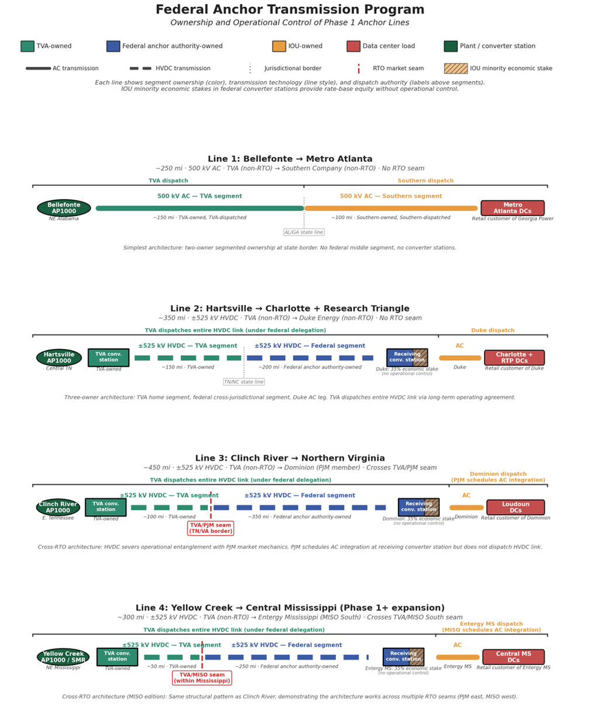

Phase 1 anchor line ownership architecture. Each line shows segment ownership (color), transmission technology (line style), and dispatch authority. The four lines follow consistent patterns adapted to their specific cross-RTO/jurisdictional contexts: Bellefonte→Atlanta is the simplest two-owner AC architecture (no RTO seam); Hartsville→Charlotte and the cross-RTO HVDC lines (Clinch River→Northern Virginia crossing TVA/PJM seam, Yellow Creek→Central Mississippi crossing TVA/MISO South seam) follow a three-owner pattern with TVA home segment, federal cross-jurisdictional segment, and destination IOU AC leg, with IOU minority economic stakes (35%) in the receiving converter stations providing rate-base equity without operational control.

### Hyperscaler Offtake: Wholesale-to-Retail

The wholesale-to-retail offtake structure runs: TVA acquires the federally-built plant and sells wholesale at acquisition-price-derived cost to the destination IOU under a long-term capacity contract. The destination IOU sells retail to hyperscaler data center customers under PPAs that incorporate the wholesale cost plus IOU margin and incorporate Fund contributions. The hyperscaler retail relationship stays with the IOU; the IOU recovers transmission rate base on its segment; TVA recovers its acquisition cost through the wholesale rate.

This preserves the IOU’s retail customer relationship (which the IOU values for distribution rate-base, retail margin, and long-term customer relationships) while routing the federal anchor program’s wholesale clean firm capacity through public-utility intermediation rather than IOU-direct ownership.

## The Reliability Vintage Architecture

Version 1.0 of this proposal treated the anchor lines as primarily a delivery mechanism — sized to the contracted wholesale share with engineering headroom and upgrade pathway provisioning for future capacity additions financed against future contracted demand. This framing was structurally honest for what it covered but left an important question unaddressed: Winter Storm Elliott cited as operational justification for new interregional transmission concerned a resource adequacy use case (asymmetric stress events where geographic diversity allows utilities to lean on each other’s non-stressed conditions) that the contracted-vintage-only sizing didn’t fully realize. A line sized only to contracted demand delivers the contracted flow reliably but doesn’t provide substantial bidirectional emergency exchange capability during stress events.

The honest accounting of what anchor lines actually buy for reliability requires recognizing that the federal anchor plant produces fixed nameplate output and the line moves that output between TVA and the destination region. During grid stress, the line’s bidirectional dispatch allows TVA to reclaim contracted flow for in-territory use or to import emergency capacity from the destination RTO — but these flows reallocate existing capacity rather than producing new capacity. The reliability story has three components: in-territory generation (largest, transmission-independent — exists with or without anchor transmission), resource adequacy in the destination region from contracted wholesale flow (also primarily a generation benefit), and bidirectional emergency exchange capability (the transmission-specific benefit).

The bidirectional capability is bounded by what’s available on the other side of the seam. TVA importing from PJM only helps if PJM has surplus; if both regions are stressed, the line doesn’t help. The most useful capability is during asymmetric stress — TVA stressed but PJM not, or vice versa. Winter Storm Elliott was actually symmetric across the broader Eastern Interconnection, where interregional transmission provides less benefit than the classical case suggests. Asymmetric events do happen, and the line provides real value during them, but they’re a smaller share of the stress event landscape than the classical case implies.

Version 2.0 therefore sizes the anchor lines explicitly with a defined **reliability vintage** of 300-500 MW per line of bidirectional emergency exchange capability on top of the contracted vintage. This is meaningfully smaller than the fleet-scale sizing pure interregional transmission framing might support, but meaningfully larger than right-sized sizing pure contracted-demand framing produces. The reliability vintage delivers genuine asymmetric-stress-event value while not overstating what the line can do during symmetric stress.

The reliability vintage sizing has direct cost-recovery implications. The 300-500 MW per line of additional physical infrastructure doesn’t produce contracted commercial revenue, but it requires capital investment and carrying costs that have to be recovered from somewhere. Under straightforward rate-basing, this carrying cost would flow to contracted vintage customers — exactly the cross-subsidy problem the right-sized approach was designed to avoid. The layered cost recovery architecture described below resolves this by allocating reliability vintage carrying cost across multiple constituencies with each paying a defined share calibrated to its benefit incidence.

## The Layered Cost Recovery Architecture

Both nuclear construction cost overruns and reliability vintage carrying cost are recovered through layered stacks where every constituency with structural interest pays a defined share. This generalized layered architecture replaces Version 1.0’s simpler three-layer Nuclear Construction Reserve Fund framing and addresses two structural problems that critics correctly identified in Version 1.0: the moral hazard concern about federal cost-overrun absorption with no POU first-loss exposure, and the cost recovery problem for the reliability vintage that wasn’t addressed at all.

### The Cost Overrun Stack

The cost overrun stack runs across four parties:

| Layer | Coverage | Party | Mechanism |
| --- | --- | --- | --- |
| Federal construction | 0-100% acquisition price | Federal balance sheet | Treasury borrowing or appropriations during construction |
| POU first-loss | 100-120% | TVA (or Phase 2 POU acquirer) | Rate base absorption through wholesale rates |
| Fund | 120-150% | Hyperscaler offtakers via Fund | Per-MWh contributions on offtake |
| Federal tail | >150% | Federal balance sheet | Treasury borrowing or appropriations |

The 100-120% POU absorption layer addresses the moral hazard concern that Version 1.0’s three-layer structure didn’t solve. Federal cost-overrun absorption with no POU first-loss exposure created an incentive structure where the operating utility had limited financial accountability for construction cost performance. The POU absorbing 20% of overruns in the modal range provides genuine financial incentive to manage construction costs aggressively. The federal supports above 120% provide the necessary backstop without eliminating POU accountability.

For TVA, the 100-120% absorption layer requires institutional buy-in and TVA Act amendment to accommodate contingent capital absorption authority. For Phase 2 POUs (NYPA, NPPD, LADWP), equivalent state-level institutional commitments are required. The POU absorption is bounded exposure manageable through standard rate-base mechanisms; the Fund and federal tail cover catastrophic overrun scenarios that would otherwise destabilize the POU balance sheet.

### The Reliability Vintage Capacity Recovery Stack

The reliability vintage capacity recovery stack runs across the same four parties with different shares calibrated to benefit incidence:

| Layer | Approximate Share | Party | Mechanism |
| --- | --- | --- | --- |
| POU | ~15% | TVA | TVA wholesale rate (reflects TVA’s resource adequacy benefit) |
| Destination IOU | ~15% | Dominion/Southern/Duke/Entergy MS | State-regulated retail rate base (reflects destination region benefit) |
| Fund | ~50% | Hyperscaler offtakers via Fund | Per-MWh contributions (reflects hyperscalers’ role as principal load-growth drivers) |
| Federal | ~20% | Federal appropriations | Bounded tail commitment |

For the four Phase 1 pilots, the aggregate annualized reliability vintage carrying cost is approximately $300-450 million per year, split: TVA wholesale rate absorption ~$45-67M/year, destination IOU rate base absorption ~$45-67M/year, hyperscaler Fund contributions ~$150-225M/year, federal appropriations ~$60-90M/year.

The destination IOU absorption layer requires state PUC approval through a specific regulatory framing developed below (“State PUC Defensibility”). The POU absorption layer requires TVA institutional commitment (and equivalent for Phase 2 POUs). The hyperscaler Fund layer operates through the same mechanical per-MWh contribution structure as the cost overrun layer, with the contribution rate covering both layers under aggregate calibration. The federal appropriations layer requires annual Congressional appropriations.

### Why the Layered Architecture Is Better

The layered architecture matches cost incidence to benefit incidence across every constituency with structural interest in the program. Each layer is bounded — POU absorption is capped at 20% of cost overruns and ~15% of reliability vintage; destination IOU absorption is capped at ~15% of reliability vintage with no cost overrun exposure; hyperscaler contributions are bounded by the Fund’s aggregate calibration; federal commitment shrinks to a meaningful but bounded tail commitment on both stacks. No party bears full cost; no party is fully insulated from cost.

The layered architecture also addresses the political defensibility problem that Version 1.0’s structure faced. The federal commitment under Version 1.0 was substantial and exposed to appropriations cycle politics; Version 2.0’s layered structure shrinks the federal commitment to bounded tail roles and shifts the principal funding burden to the hyperscaler beneficiary class through structured Fund contributions. The federal role becomes catalyst and tail-risk absorber rather than principal funder.

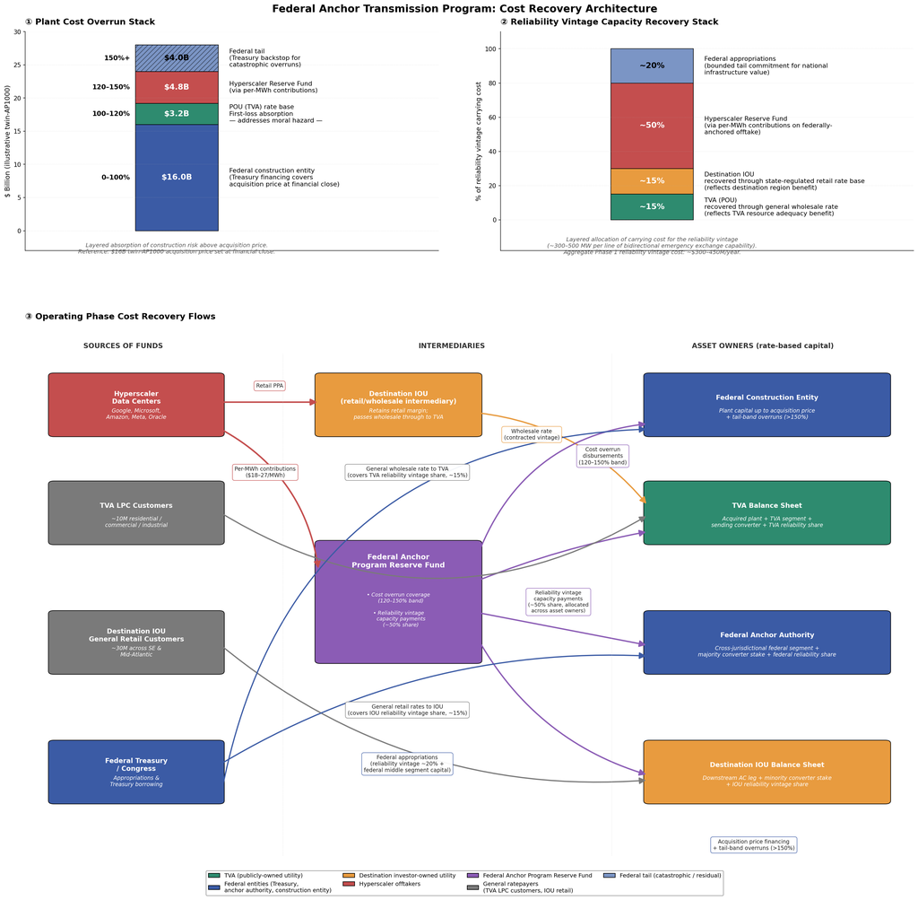

Federal Anchor Transmission Program Cost Recovery Architecture, showing the plant cost overrun stack (federal construction up to acquisition price, POU first-loss 100-120%, hyperscaler Reserve Fund 120-150%, federal tail above 150%), the reliability vintage capacity recovery stack (TVA ~15%, destination IOU ~15%, hyperscaler Reserve Fund ~50%, federal appropriations ~20%), and the operating-phase cost recovery flows showing how funds move from sources (hyperscaler PPAs, TVA LPC customer wholesale rates, destination IOU general retail rates, federal Treasury) through intermediaries (Reserve Fund, destination IOUs) to asset owners (federal construction entity, TVA balance sheet, Federal Anchor Authority, destination IOU balance sheet).

## The Federal Anchor Program Reserve Fund

The original Nuclear Construction Reserve Fund expands to a **Federal Anchor Program Reserve Fund** administering both coverage layers under unified administration. The Fund’s expanded design is more administratively complex than Version 1.0’s framing but is structurally more complete.

### Contribution Structure

Hyperscaler per-MWh contributions on offtake from federally-anchored plants fund both layers. The contribution rate aggregates to $18-27/MWh across both layers: approximately $10-15/MWh for the cost overrun coverage layer (120-150% band) plus approximately $8-12/MWh for the reliability vintage capacity payment layer (50% layer). This is substantially lower than $40-55/MWh under single-layer single-payer approaches because POU, destination IOU, and federal absorption layers cover meaningful shares of both stacks.

For a hyperscaler offtaking 1,000 MW at 90% capacity factor, the total Fund contribution is approximately $140-215 million per year per plant. Across the Phase 1 fleet of four plants, aggregate hyperscaler contributions are roughly $560 million to $860 million per year.

### Uniform Rate-Setting and the First-Mover Problem

The Fund’s contribution rate is set uniformly across all participating hyperscalers within defined rate-setting intervals (probably 5-year periods), with rate adjustments at interval boundaries based on accumulated fleet experience. Without uniform rate-setting, sophisticated hyperscaler procurement teams would recognize that delay is rewarded by lower future rates (because early pilots face higher concentrated risk than later ones), no individual hyperscaler would benefit from going first, and the program might never reach first financial close. Uniform rate-setting eliminates this coordination failure by ensuring all PPAs signed within an interval pay the same rate regardless of which pilot they’re contracting with or when within the interval they sign.

The structural trade-off is that uniform rate-setting transfers some risk to the federal tail-band that would otherwise have been absorbed through differentiated early-pilot premiums. The federal tail-band exposure is bounded and is appropriately federal in any case, but the program design should acknowledge that uniform rate-setting modestly increases expected federal tail-band engagement compared to pure actuarial rate-setting. This is an acceptable trade-off because eliminating the first-mover penalty is essential to program viability.

The uniform rate-setting commitment must be statutorily defined to provide the credible signal that ad hoc administrative practice would not. The federal authorizing legislation should specify the methodology with statutory definition of interval lengths, calibration procedures, and rate adjustment protocols.

### Construction-Period Advance Contributions

Hyperscaler contributions begin during the construction period rather than waiting for commercial operation. PPA contracts include advance contribution provisions calibrated as a fraction of expected lifetime operational contributions, paid annually during construction with credits applied against operational contributions once delivery begins. Without these advance contributions, the Fund would have essentially no reserves when the first pilot reaches commercial operation, leaving the coverage band nominally available but functionally empty for the earliest pilots. The advance contribution rate is calibrated so that across the construction period (6-10 years for AP1000 deployments), Fund reserves accumulate to roughly $2-4 billion by the time the first pilot reaches commercial operation — adequate for early-pilot coverage even if a Vogtle-scale overrun emerges.

The mechanism is structurally analogous to CWIP (Construction Work in Progress) financing in utility ratemaking, with three differences that distinguish it from traditional CWIP. Cost-bearers are the program’s direct beneficiaries (hyperscaler offtakers) rather than the general ratepayer base. Funds flow into the federal trust fund as protected reserves rather than into general utility revenue. The commercial commitment is voluntary at the individual hyperscaler PPA level rather than imposed through rate-case proceedings. The cost discipline accountability that’s traditionally a concern with CWIP operates through other layers of the cost overrun stack — federal construction entity, POU first-loss absorption, Fund administration — rather than relying on the advance contribution mechanism itself. If a pilot is cancelled during construction, advance contributions remain in the Fund as part of the broader Phase 1 reserve pool rather than being refunded; this is consistent with the Fund’s risk-pooling logic and is a bounded commercial concession from hyperscalers.

### Administration and Governance

The Fund is administered by Treasury or DOE as a dedicated federal trust fund. Disbursements flow against documented cost overruns in the hyperscaler band (120-150% of acquisition price for each project) and annual capacity payments to anchor line asset owners (TVA, destination IOU, federal authority) under defined formulas. Excess accumulation can be returned to contributing hyperscalers pro rata, applied to plant decommissioning reserves, or rolled forward to subsequent generation in the program. The Fund’s governance includes federal oversight with transparent annual reporting on inflows, outflows, and accumulated reserves.

## State PUC Defensibility: The Package-Deal Framing

The destination IOU absorption layer for reliability vintage carrying cost requires state PUC approval, and the substantive grounds for approval deserve specific attention because the reliability vintage doesn’t fit neatly into standard rate base prudency analysis. The reliability vintage doesn’t earn capacity accreditation under PJM, MISO South, or other RTO market mechanisms (per MISO’s December 2025 HVDC Whitepaper, “no RTO in North America currently allows transmission lines to earn capacity credit”). Under standard prudency analysis, the question is what concrete benefit retail customers receive in exchange for paying these rates.

The **package-deal framing** answers this by reframing the state PUC’s review unit. The PUC isn’t approving the reliability vintage as standalone infrastructure requiring independent prudency review. The PUC is approving the IOU’s participation in the federal anchor program as a whole, with the reliability vintage as one component of overall participation that delivers substantial state-level benefits: federally-supported clean firm capacity at acquisition-price wholesale cost (substantially below equivalent IOU-built nuclear); federally-financed transmission infrastructure that wouldn’t otherwise be built; supplemental bilateral reliability capability through emergency exchange with TVA; continued infrastructure investment supporting load growth.

Virginia presents the strongest substantive case. Virginia’s regulatory environment uniquely combines binding state RPS legislation (the Virginia Clean Economy Act), the most concentrated data center load growth in the world, and PJM membership with PJM’s recently volatile capacity market (2026/27 and 2027/28 BRA cleared at the FERC cap of $329-333/MW-day). The federal anchor program addresses Virginia-specific structural pressures that PJM’s market mechanisms aren’t resolving on their own. Prospective VCEA amendment to include nuclear in the carbon-free definition would strengthen the case further by adding direct VCEA compliance value, though the package-deal framing under current VCEA is substantively defensible without amendment. The other Phase 1 destination states (North Carolina, Georgia, Mississippi) present calibrated versions of similar logic with somewhat less acute structural conditions.

## Operational Mechanics: Sequencing and PPA Allocation

Phase 1 pilots subscribe in parallel rather than sequentially, with minimum subscription thresholds (probably two or three pilots committed before any individual pilot reaches financial close) maintaining Fund risk-pooling diversification. The Federal Anchor Authority verifies subscription requirements before authorizing individual pilots to proceed to financial close. Phase 2 pilots subscribe as their public power acquirers and destination IOU partners are ready, without waiting for Phase 1 completion. Subscription requires (a) IOU partner commitment to wholesale offtake, (b) hyperscaler retail PPAs signed under uniform rate-setting, and (c) hyperscaler Fund contribution commitments in place.

Hyperscaler PPA allocation within destination IOU territories is the IOU’s responsibility under state PUC oversight, not a federal procurement decision. The likely allocation mechanism in each destination state blends bilateral negotiation with existing major customers (dominant, given concentrated hyperscaler presence in each destination state), competitive RFP for residual capacity, and state economic development considerations influencing negotiation terms. The federal program structure constrains the framework but leaves specific allocation decisions to the destination IOU under state regulatory oversight. Federal oversight focuses on Fund contribution rate compliance and subscription threshold verification rather than on dictating specific PPA terms.

## Protecting Against Market Integration Pressure

The reliability vintage’s existence creates a structural vulnerability that opponents could exploit. The 300-500 MW per line of physical capacity sitting unused most of the time invites the argument that it should be commercialized through an energy imbalance market — expansion of SEEM to include TVA, or bilateral EIM-style arrangements between TVA and PJM/Duke/MISO South across the new physical interconnections — with the reliability vintage capacity sold into the market when not needed for stress events. The “wasted infrastructure” framing is politically resonant in cost-conscious environments where any unused asset looks like ratepayer money sitting idle.

This is a Trojan horse for market integration. EIM participation creates regular operational data flows, real-time price signals influencing dispatch, and ongoing operational integration. Over time the boundary between TVA and the destination RTOs becomes more permeable even if TVA’s formal legal independence remains intact. Once TVA is running real-time settlement against PJM or MISO price signals, it’s effectively participating in those markets without formal membership. The historical analog is BPA’s ongoing pressure to integrate into CAISO’s Western EIM, which BPA has resisted only through strong institutional commitment rather than through any structural feature preventing pressure from accumulating.

The proposal lives in tension with the interregional transmission advocate community on this point. The advocate consensus across Grid Strategies, ACEG, Brattle, ESIG, Niskanen, RMI, and others is that uncommitted interregional capacity should be compensated through ELCC accreditation and intertie optimization (real-time market participation), not deliberately walled off from markets. The Brooks/Silverstein/Gramlich June 2025 Grid Strategies report “Resource Adequacy Value of Interregional Transmission” is the most developed analytical framework, and it explicitly contemplates RA value “even without firm generation associated with the facility” — but it does not affirmatively endorse leaving the reliability vintage uncompensated. The dominant critique in the advocate literature is **economic underutilization** (capacity not earning revenue when it has value), not physical underutilization per se. A reliability vintage that flows at 5-10% physical utilization would not be criticized *if* every economic price spread justifying flow is captured; but if the vintage is institutionally walled off from real-time markets, the advocate community would press for it to be enrolled in EIM/SEEM/CTS-equivalent intra-hour optimization.

The program’s design choice is to wall off the reliability vintage from commercial dispatch markets. Several structural protections foreclose the commercialization pathway. Federal authorizing legislation should explicitly reserve the reliability vintage capacity for emergency exchange use only, with no commercial dispatch outside defined emergency conditions and no eligibility for participation in any commercial dispatch market (RTOs, EIMs, bilateral commercial arrangements). The Federal Anchor Authority retains dispatch control over cross-jurisdictional reliability vintage segments under defined emergency protocols, with no third-party RTO or EIM administrator having dispatch authority. TVA retains operational dispatch rights over its home-jurisdiction segment, with interregional cooperation operating through bilateral emergency exchange agreements rather than commercial market mechanisms.

The layered cost recovery architecture is itself the strongest political defense. The “wasted infrastructure” framing depends on characterizing the capacity as ratepayer money sitting idle, but if hyperscalers are explicitly paying for it as reliability infrastructure they benefit from, ratepayers’ share is bounded (15% for destination IOU customers, 15% through TVA wholesale rates), and federal appropriations cover the tail share, the political framing collapses. The capacity isn’t “wasted” — it’s reserved infrastructure that every party with stake understands and is paying for as such.

The honest acknowledgment is that political pressure for commercialization will accumulate over time as the new physical interconnections become routine and as cost-conscious appropriations cycles probe for ways to reduce federal commitment. The protections are necessary but not sufficient on their own. Sustaining the program’s structural integrity will require ongoing political commitment from public power constituencies and from federal program leadership across multiple administrations. The proactive framing — that the reliability vintage is reserved emergency infrastructure paid for under a defined cost recovery architecture, and that commercialization would compromise the structural integrity of TVA’s market independence — has to be established in the program’s written record and in proponent advocacy from the beginning.

## Federal Financing Architecture

The proposal leverages multiple federal financing instruments already in place and adds modest new authority where needed. For **construction-phase financing of plants**, the existing toolkit is largely sufficient: the DOC/Westinghouse/Brookfield/Cameco $80 billion partnership, the Office of Energy Dominance Financing’s credit support authority, Treasury borrowing through DOE or DOC appropriations, and IRA tax credits (Sections 45U, 48E, with possible restructuring to flow to federal construction entities).

For **TVA’s acquisition financing**, modest debt cap relief is needed — raising the cap from $30 billion to $50-60 billion or creating a dedicated acquisition-financing exception. For **anchor line financing**, federal credit enhancement reduces capital cost for federal and IOU segments through the Office of Energy Dominance Financing’s expanded “energy infrastructure” lending mandate, with a dedicated federal credit facility for federally-anchored interregional transmission as a further enhancement. For **the Federal Anchor Program Reserve Fund**, the fund is administered by Treasury or DOE and is funded by hyperscaler contributions plus federal appropriations for the federal layers in the cost recovery stacks.

## What’s In It for Each Stakeholder

The proposal’s durability depends on every major stakeholder having a clear and defensible stake in the program’s success.

**TVA** gains scale expansion of its operating nuclear fleet without bearing the catastrophic share of construction risk (the 100-120% POU absorption layer is bounded), rate-base position in new interregional transmission for its segments of anchor lines, revenue from long-term wholesale capacity contracts with neighboring IOUs that diversify its customer base, and the fleet workhorse role hosting a substantial share of national AP1000 buildout. The TVA CEO’s commitment that data center growth won’t pressure rates for other electric customers is structurally preserved — catastrophic overruns above 120% are absorbed federally or through the Fund, not flowing into TVA’s rate base.

**Neighboring IOUs (Southern, Duke, Dominion, Entergy Mississippi)** gain rate-base position in their segments of anchor transmission, retail customer relationships with hyperscalers preserved, access to firm clean capacity at federally-financed cost without taking construction risk, and an accelerated solution to data center capacity shortfalls they cannot independently solve. The reliability vintage absorption (~15% via state-regulated rate base) is bounded exposure recoverable under the package-deal framing. The IOU’s other program benefits more than offset the additional reliability vintage absorption.

**Hyperscalers** gain access to long-term firm clean energy at predictable cost on a timeline meaningful to their AI infrastructure investments. The $18-27/MWh total Fund contribution covers both cost overrun and reliability vintage layers and is substantially lower than single-layer approaches would require. The fleet-wide risk pooling and uniform rate-setting eliminate first-mover penalty dynamics. Catastrophic overruns above 150% of acquisition price are absorbed federally.

**TVA’s roughly 10 million residential and LPC customers** are the demographic that has historically borne the worst of nuclear cost overruns. Under the federal-balance-sheet construction model with bounded POU absorption, this category of harm is largely eliminated for new nuclear. TVA residential customers also benefit from the new clean firm generation serving in-territory growth and from the resource adequacy improvements that come with new interregional ties (the reliability vintage’s bidirectional emergency exchange capability).

**IOU residential customers (approximately 30 million across the Phase 1 destination states)** benefit from federally-supported clean firm capacity reaching their utility through wholesale arrangements rather than IOU-built nuclear with full construction-cost-overrun pass-through. The reliability vintage absorption flowing through general retail rates (~$1-3 per retail customer per year) is a small marginal cost for substantial resource adequacy benefit.

**The federal government** retains the catalyst role its New Deal predecessors established but with the financial commitment bounded by the layered architecture. Federal exposure on the cost overrun stack is limited to the 0-100% construction phase plus catastrophic tail above 150%; on the reliability vintage stack to approximately $60-90 million per year across the four Phase 1 pilots. The federal role becomes catalyst and tail-risk absorber rather than principal funder.

## Pilot Strategy

### Phase 1: TVA Pilots

[figure not shown]

Each pilot has 300-500 MW reliability vintage on top of contracted capacity. Aggregate Phase 1 contracted vintage: ~4,900 MW. Aggregate Phase 1 with reliability vintage: ~6,300 MW. Phase 1 demonstrates the framework across both eastern (PJM seam via Dominion) and western (MISO South seam via Entergy MS) cross-RTO interconnections, plus internal Southeast (Southern, Duke).

### Phase 2: Other Public Utility Pilots

**NYPA SMR or AP1000 with downstate IOU offtakers.** Federally-built nuclear at a New York site, transferred to NYPA, with wholesale share to Con Edison and National Grid for downstate New York and northern New Jersey data center load. The pilot establishes the framework works in a different regulatory environment (NYS PUC, NYISO market structure).

**Nebraska public power AP1000 with regional IOU offtakers.** Federally-built AP1000 at an NPPD-selected site, transferred to NPPD, with wholesale to MISO and SPP IOUs serving Omaha, Kansas City, and broader Midwest data center clusters. Demonstrates portability to 100%-public-power state structure and MISO/SPP regional conditions.

**LADWP pilot in the Western Interconnection.** Federally-built clean firm project (nuclear or geothermal depending on California regulatory pathway), acquired by LADWP, with anchor transmission improvements coordinated with existing Pacific Intertie infrastructure. LADWP’s existing role as Pacific Intertie co-owner makes it the natural Western Interconnection pilot.

### Fleet-Scale Outlook

TVA’s pre-assessed sites alone support 8-12 GW of new nuclear capacity beyond Phase 1. Phase 2 POUs could add another 10-20 GW. The framework supports a multi-decade federally-built clean firm deployment program at scale meaningful to projected load growth across multiple regions.

## Legislative and Administrative Requirements

The proposal can be implemented through a combination of administrative action under existing authorities and new legislation.

**Available under existing authority:** Federal construction-phase ownership of capital projects, DOE Loan Programs Office credit support, IRA tax credits (with possible restructuring), the DOC/Westinghouse $80 billion partnership, FERC transmission incentives under Order 679.

**Requiring new legislation:**

*Federal Anchor Generation Authority.* New legislation authorizing federal construction-phase ownership of clean firm generation plants, with defined transfer mechanisms to acquiring utilities at agreed acquisition prices. Defines eligible projects, eligible acquirers under the modernized public-preference principle, and the acquisition price methodology. Eligibility is explicitly limited to publicly-owned utilities.

*Federal Anchor Program Reserve Fund.* Statutory establishment as a dedicated trust fund administered by Treasury, with defined inflow rules (per-MWh contributions from hyperscaler offtakers), outflow rules (disbursements for documented cost overruns in the hyperscaler band plus reliability vintage capacity payments), governance, and statutorily defined contribution rate methodology (uniform rate-setting within defined intervals plus construction-period advance contributions).

*Federal cost-overrun absorption authority.* Statutory authorization for federal absorption of construction costs above the hyperscaler band, drawn from Treasury borrowing or Congressional appropriations.

*POU cost recovery layer authorities.* TVA Act amendments to accommodate the 100-120% POU absorption layer for cost overruns and the ~15% absorption for reliability vintage carrying cost. Equivalent state-level authorities for Phase 2 POUs.

*TVA Act amendments.* In addition to the cost-recovery amendments above: a narrow fence carve-out authorizing TVA to sell power from federally-acquired anchor program plants on a wholesale basis to neighboring IOUs; expansion of TVA’s statutory debt limit (raising the cap from $30 billion to $50-60 billion, or creating a dedicated acquisition-financing exception).

*Federal transmission siting authority.* Renewed federal backstop siting authority for anchor lines tied to federally-supported clean firm generation, limited specifically to anchor program lines for narrower scope and stronger constitutional footing.

*Reliability vintage statutory protections.* Explicit reservation of reliability vintage capacity for emergency exchange use only, with prohibition on participation in commercial dispatch markets (RTOs, EIMs, bilateral commercial arrangements). Federal Anchor Authority and TVA dispatch control specifications.

**Requiring administrative action:** Standardized federal joint-project documentation template for anchor lines. Interagency coordination among DOE, DOC, FERC, TVA, NRC, and Treasury. A federal Anchor Program Office to administer program criteria, evaluate candidate projects, oversee construction-phase activities, manage plant transfers, administer the Fund, and coordinate federal support packages.

## Why This Approach Optimizes Buildout

The proposal optimizes interregional transmission buildout for five reasons specific to the modern political, economic, and risk environment.

It **removes construction-cost-overrun risk as a barrier to buildout.** The federal-balance-sheet construction model plus the layered cost recovery architecture means no single party absorbs the catastrophic-overrun risk that has prevented new nuclear from being built at scale since Vogtle. Every other element of the proposal becomes possible only because this central risk-absorption problem is solved.

It **converts each new federally-supported clean firm generation project into an interregional transmission opportunity.** Every new federally-built AP1000 or SMR becomes a candidate for an anchor line. The transmission pipeline scales with the federal generation pipeline.

It **defuses IOU opposition at the design stage rather than fighting it at the regulatory stage.** The IOU has a transmission rate-base position, a retail customer relationship preserved, accelerated access to firm clean capacity, and bounded construction risk exposure (only via the package-deal-framed reliability vintage absorption). It has no structural reason to oppose the program.

It **avoids the cost-allocation fight that kills modern interregional projects.** The Pacific Intertie ownership pattern settles transmission cost allocation through ownership rather than contested allocation methodology. The layered cost recovery architecture extends ownership-based allocation across reliability vintage carrying cost.

It **uses the federal toolkit that already exists, plus targeted new authorities where needed.** Most financial and regulatory instruments are already in place; the new authorities required are substantive but coherent and can be enacted as a single integrated package.

## Conclusion

The United States built its last great interregional transmission corridor sixty years ago through a New Deal model that combined federal capital project construction, public-utility operation under a statutory preference principle, joint segmented transmission ownership, federal financing, and reciprocal regional benefit. The corridor has operated reliably for 55+ years.

This proposal generalizes that New Deal model to the 21st-century clean firm generation challenge through four essential moves. First, the federal-balance-sheet construction model is extended from federal hydropower to federally-supported clean firm generation, with publicly-owned utilities as acquiring operators. Second, the public-preference principle is modernized: federal supports flow to public power preferentially in cost-overrun absorption and transmission financing/siting authority. Third, the anchor lines are explicitly sized with a defined reliability vintage that delivers genuine bidirectional emergency exchange capability — addressing the resource adequacy use case that Winter Storm Elliott exposed. Fourth, both nuclear construction cost overruns and reliability vintage carrying cost are recovered through a generalized layered architecture in which every constituency with structural interest pays a defined share calibrated to its benefit incidence.

The Federal Anchor Program Reserve Fund administers both layers under unified administration, with hyperscaler contributions in the $18-27/MWh range covering the largest share of both stacks. Uniform rate-setting within defined intervals eliminates the first-mover penalty that would otherwise prevent the program from reaching first financial close. Construction-period advance contributions (structurally analogous to CWIP but with key structural improvements) provide bootstrap reserves so the Fund’s coverage is functionally available when the first pilot reaches commercial operation.

The proposal lives in tension with the interregional transmission advocate community whose preference is to commercialize all uncommitted capacity through ELCC accreditation and market-eligible dispatch. The proposal’s design choice — to reserve the reliability vintage for emergency exchange use with explicit statutory protections against commercial dispatch market participation — is structurally defensible (the layered cost recovery makes the “wasted infrastructure” framing collapse) but politically demanding. Sustaining the program’s structural integrity will require ongoing political commitment from public power constituencies across multiple administrations.

Federal Anchor Transmission, as outlined here, is the Bureau of Reclamation / BPA / Pacific Intertie template applied to a portfolio of federally-built clean firm generation projects, with TVA and other qualifying publicly-owned utilities as fleet operators under a modernized public-preference principle, with hyperscaler offtakers as risk-sharing program participants under a layered cost recovery architecture, and with the existing federal financing, industrial-base, and tax credit toolkit as the support infrastructure. It can deliver multiple new interregional corridors within a decade, at a scale meaningful to data center load growth currently overwhelming individual IOU planning horizons, with structural features that align participating IOUs as project partners rather than project opponents, protect public-utility ratepayers from catastrophic construction risk while preserving meaningful accountability through bounded POU first-loss exposure, place catastrophic risk where it can be absorbed (on the federal balance sheet), and preserve the public-private distinction that has long structured federal power policy.

It is the most plausible path currently available to substantial new interregional transmission buildout in the United States, and it does so by extending — rather than departing from — the federal power infrastructure tradition that has demonstrably worked for nearly a century.